# Final IST 652 6-12

## IST 652 Final Project Program

### The following steps will be taken import libraries, load , inspect, clean, and merge data for exploratory data analysis and invetigation.

### Section 1 Questions : What was the effect of the Covid pandemic on Tesla’s stock value? & Do Tesla’s stock prices and Dogecoin’s market value exhibit similar responses to Elon Musk’s tweets? Alternatively, does the market’s response to Dogecoin affect the share price of Tesla?

### Section 2 Questions : How will Tesla stock prices trend in the future? Construct a predictive model.

### Section 3 Question: How do Elon Musk's tweets affect stock market Movements? Can this sentiment be measure though sentiment analysis?

### By: Padmaja Kurumaddali, Sarah Morris, & Sachi Singh

Load in all required libraries

```python
import pandas as pd
import numpy as np
import matplotlib.pyplot as plt
import seaborn as sns
import re
import nltk
from nltk.corpus import stopwords
from nltk.stem import WordNetLemmatizer
from nltk.tokenize import word_tokenize
from sklearn.model_selection import train_test_split, GridSearchCV
from sklearn.feature_extraction.text import TfidfVectorizer
from sklearn.linear_model import LogisticRegression
from sklearn.svm import SVC
from sklearn.ensemble import RandomForestClassifier
from sklearn.metrics import (accuracy_score, precision_score, recall_score, f1_score,
                             classification_report, confusion_matrix, ConfusionMatrixDisplay, roc_auc_score)
from sklearn.naive_bayes import MultinomialNB
from sklearn.preprocessing import StandardScaler
from wordcloud import WordCloud
import xgboost as xgb
from xgboost import XGBClassifier
from prophet import Prophet
import warnings

warnings.filterwarnings('ignore')
nltk.download('punkt')
nltk.download('stopwords')
nltk.download('wordnet')
```

```
True
```

Load in three dataset : Tesla Stock, Dogecoin Perforamce, and Elon Musk Tweets.

```python
# Define the dataset columns
DATASET_COLUMNS = ['date', 'time', 'tweet', 'replies_count', 'retweets_count', 'likes_count']

# Load the datasets
dogecoin_df = pd.read_csv(r"C:\Users\sgsin\OneDrive\Desktop\IST 652 Data\Dogecoin 2017-2024.csv")
elon_tweets_df = pd.read_csv(r"C:\Users\sgsin\OneDrive\Desktop\IST 652 Data\Elon_Tweets_2011_2021.csv")
tesla_stock_df = pd.read_csv(r"C:\Users\sgsin\OneDrive\Desktop\IST 652 Data\Tesla_Stock_2014_2023.csv")
```

Inspect data, review descriptive stats, and clean: Displaying the first few rows, descriptive statistics, dataset shapes, data types, presence of null values, unique values, conversion of date columns to datetime format, addition of columns for year, month, day, and daily returns in the Tesla stock data, and finally, viewing the columns in each dataset.

```python
# Print head of datasets
print(elon_tweets_df.head())
print(tesla_stock_df.head())
print(dogecoin_df.head())

# Descriptive statistics
print('Below shows the Descriptive Statistics of the Elon Musk Tweets data')
print(elon_tweets_df.describe())

print('Below shows the Descriptive Statistics of the Tesla Stock data')
print(tesla_stock_df.describe())

print('Below shows the Descriptive Statistics of the Dogecoin data')
print(dogecoin_df.describe())

# Shape of datasets
print(elon_tweets_df.shape)
print(tesla_stock_df.shape)
print(dogecoin_df.shape)

# Info about datasets
elon_tweets_df.info()
tesla_stock_df.info()
dogecoin_df.info()

# Data types of columns
print('List of datatypes for each column:', elon_tweets_df.dtypes)
print('List of datatypes for each column:', tesla_stock_df.dtypes)
print('List of datatypes for each column:', dogecoin_df.dtypes)

# Null values
print('List of the Nulls in the Elon Musk Data:', elon_tweets_df.isnull().sum())
print('List of the Nulls in the Tesla Stock Data:', tesla_stock_df.isnull().sum())
print('List of the Nulls in the Dogecoin Data:', dogecoin_df.isnull().sum())

# Unique values in datasets
print('Unique values in Elon Musk Data:', elon_tweets_df.nunique())
print('Unique values in Tesla Stock Data:', tesla_stock_df.nunique())
print('Unique values in Dogecoin Data:', dogecoin_df.nunique())

# Convert date columns to datetime
tesla_stock_df['date'] = pd.to_datetime(tesla_stock_df['date'])
elon_tweets_df['date'] = pd.to_datetime(elon_tweets_df['date'])
dogecoin_df['Date'] = pd.to_datetime(dogecoin_df['Date'])

# Add year, month, day, and daily_returns columns
tesla_stock_df['year'] = tesla_stock_df['date'].dt.year
tesla_stock_df['month'] = tesla_stock_df['date'].dt.month
tesla_stock_df['day'] = tesla_stock_df['date'].dt.day
tesla_stock_df['daily_returns'] = tesla_stock_df['next_day_close'] - tesla_stock_df['close']


# View columns for all datasets
print("Columns in elon_tweets_df:", elon_tweets_df.columns)
print("Columns in tesla_stock_df:", tesla_stock_df.columns)
print("Columns in dogecoin_df:", dogecoin_df.columns)
```

```
        date      time                                              tweet  \
0  4/11/2021  18:50:33  @vincent13031925 For now. Costs are decreasing...
1  4/11/2021  18:48:58                           Love this beautiful shot
2  4/11/2021  17:49:38  @agnostoxxx @CathieDWood @ARKInvest Trust the ...
3  4/11/2021  15:23:49                 The art In Cyberpunk is incredible
4  4/11/2021   9:18:47                                    @itsALLrisky 🤣🤣

   replies_count  retweets_count  likes_count
0            640             444        15281
1           2464            1517        71161
2            115              48         1380
3           8437           10329       228144
4            446             542         7489
         date       open       high       low      close    volume      rsi_7  \
0  2014-01-02   9.986667  10.165333  9.770000  10.006667  92826000  55.344071
1  2014-01-03  10.000000  10.146000  9.906667   9.970667  70425000  53.742629
2  2014-01-06  10.000000  10.026667  9.682667   9.800000  80416500  46.328174
3  2014-01-07   9.841333  10.026667  9.683333   9.957333  75511500  53.263037
4  2014-01-08   9.923333  10.246667  9.917333  10.085333  92448000  58.368660

      rsi_14       cci_7     cci_14    sma_50    ema_50    sma_100   ema_100  \
0  54.440118  -37.373644  15.213422  9.682107  9.820167  10.494240  9.674284
1  53.821521  -81.304471  17.481130  9.652800  9.826069  10.495693  9.680190
2  50.870410 -123.427544 -37.824708  9.629467  9.825047  10.496740  9.682577
3  53.406750  -84.784651 -20.779431  9.597747  9.830235  10.503407  9.688051
4  55.423026   60.799662  43.570559  9.573240  9.840239  10.511147  9.695964

       macd  bollinger  TrueRange     atr_7    atr_14  next_day_close
0  0.169472   9.740800   0.395333  0.402641  0.447550        9.970667
1  0.162623   9.776167   0.239333  0.379311  0.432677        9.800000
2  0.141790   9.797900   0.344000  0.374267  0.426343        9.957333
3  0.136402   9.837900   0.343334  0.369848  0.420414       10.085333
4  0.140837   9.870167   0.329334  0.364060  0.413908        9.835333
         Date      Open      High       Low     Close  Adj Close     Volume
0   11/9/2017  0.001207  0.001415  0.001181  0.001415   0.001415  6259550.0
1  11/10/2017  0.001421  0.001431  0.001125  0.001163   0.001163  4246520.0
2  11/11/2017  0.001146  0.001257  0.001141  0.001201   0.001201  2231080.0
3  11/12/2017  0.001189  0.001210  0.001002  0.001038   0.001038  3288960.0
4  11/13/2017  0.001046  0.001212  0.001019  0.001211   0.001211  2481270.0
Below shows the Descriptive Statistics of the Elon Musk Tweets data
```

[output cut: 228 more lines]

```
High         2107
Low          2092
Close        2110
Adj Close    2110
Volume       2334
dtype: int64
Columns in elon_tweets_df: Index(['date', 'time', 'tweet', 'replies_count', 'retweets_count',
       'likes_count'],
      dtype='object')
Columns in tesla_stock_df: Index(['date', 'open', 'high', 'low', 'close', 'volume', 'rsi_7', 'rsi_14',
       'cci_7', 'cci_14', 'sma_50', 'ema_50', 'sma_100', 'ema_100', 'macd',
       'bollinger', 'TrueRange', 'atr_7', 'atr_14', 'next_day_close', 'year',
       'month', 'day', 'daily_returns'],
      dtype='object')
Columns in dogecoin_df: Index(['Date', 'Open', 'High', 'Low', 'Close', 'Adj Close', 'Volume'], dtype='object')
```

Exploratory Data Analysis Visuals: This code generates visualizations to explore Elon Musk's tweet activity, top tweets, and total engagement over time. It also provides insights into Tesla stock trends, including closing prices, volume, and daily returns. Additionally, it offers visualizations for Dogecoin's price and trading volume. These visuals help our team gain insights for analysis and decision-making

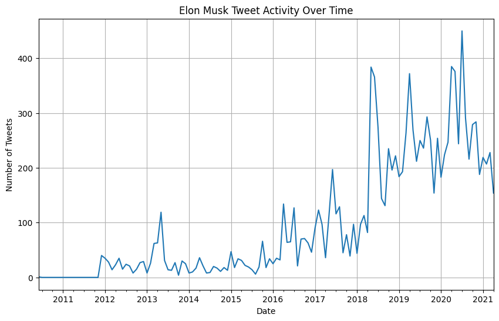

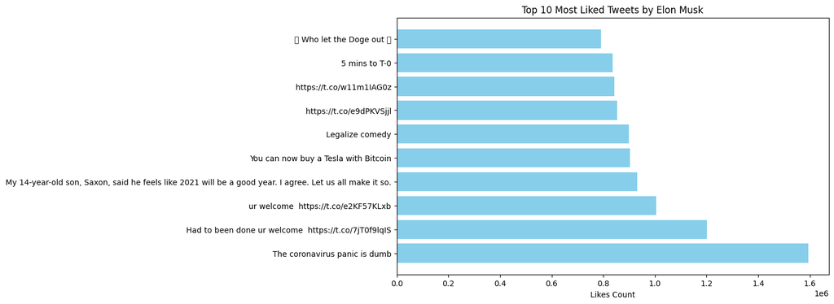

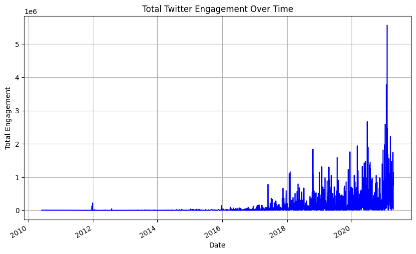

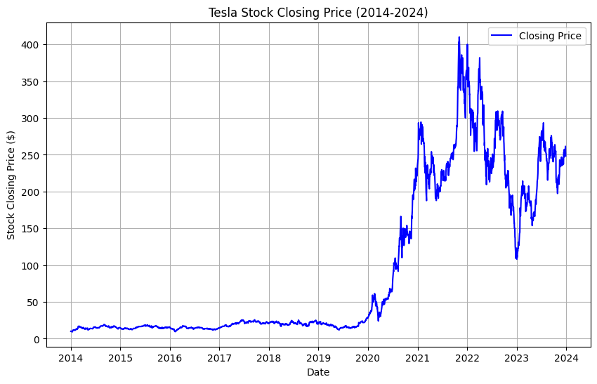

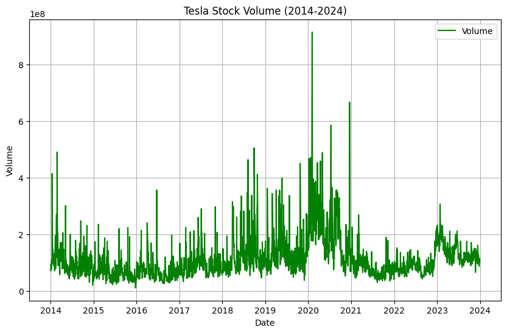

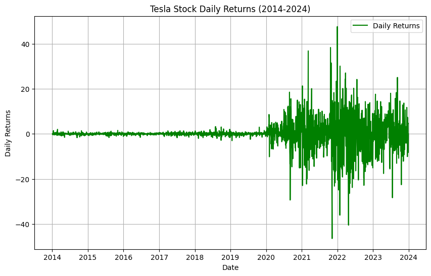

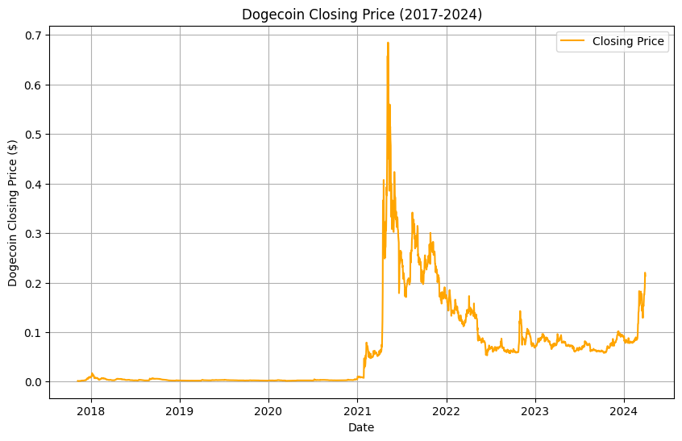

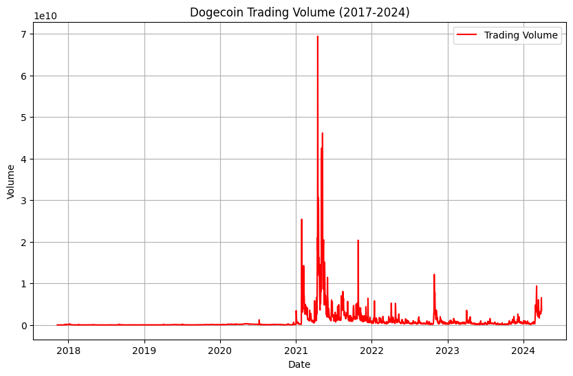

```python
#Exploratory data visuals

elon_tweets_df['date'] = pd.to_datetime(elon_tweets_df['date'])
elon_tweets_df.set_index('date').resample('M').size().plot(kind='line', figsize=(10, 6))
plt.title('Elon Musk Tweet Activity Over Time')
plt.xlabel('Date')
plt.ylabel('Number of Tweets')
plt.grid(True)
plt.show()

#Top 10 Most Liked Tweets
most_liked_tweets = elon_tweets_df.nlargest(10, 'likes_count')
plt.figure(figsize=(10, 6))
plt.barh(most_liked_tweets['tweet'], most_liked_tweets['likes_count'], color='skyblue')
plt.xlabel('Likes Count')
plt.title('Top 10 Most Liked Tweets by Elon Musk')
plt.show()


# Combine likes, replies, and retweets to calculate total engagement
elon_tweets_df['total_engagement'] = elon_tweets_df['likes_count'] + elon_tweets_df['replies_count'] + elon_tweets_df['retweets_count']

# Group by date and sum up the total engagement
engagement_over_time = elon_tweets_df.groupby('date')['total_engagement'].sum()

# Plot total engagement over time
plt.figure(figsize=(10, 6))
engagement_over_time.plot(color='blue')
plt.xlabel('Date')
plt.ylabel('Total Engagement')
plt.title('Total Twitter Engagement Over Time')
plt.grid(True)
plt.show()

#tesla Stock Over time
plt.figure(figsize=(10, 6))
plt.plot(tesla_stock_df['date'], tesla_stock_df['close'], label='Closing Price', color='blue')
plt.xlabel('Date')
plt.ylabel('Stock Closing Price ($)')
plt.title('Tesla Stock Closing Price (2014-2024)')
plt.legend()
plt.grid(True)
plt.show()

#Volume Over time
plt.figure(figsize=(10, 6))
plt.plot(tesla_stock_df['date'], tesla_stock_df['volume'], label='Volume', color='green')
plt.xlabel('Date')
plt.ylabel('Volume')
plt.title('Tesla Stock Volume (2014-2024)')
plt.legend()
plt.grid(True)
plt.show()

#tesla Returns over time
plt.figure(figsize=(10, 6))
plt.plot(tesla_stock_df['date'], tesla_stock_df['daily_returns'], label='Daily Returns', color='green')
plt.xlabel('Date')
plt.ylabel('Daily Returns')
plt.title('Tesla Stock Daily Returns (2014-2024)')
plt.legend()
plt.grid(True)
plt.show()


#Doge Price Over Time
plt.figure(figsize=(10, 6))
plt.plot(dogecoin_df['Date'], dogecoin_df['Close'], label='Closing Price', color='orange')
plt.xlabel('Date')
plt.ylabel('Dogecoin Closing Price ($)')
plt.title('Dogecoin Closing Price (2017-2024)')
plt.legend()
plt.grid(True)
plt.show()


dogecoin_df['Date'] = pd.to_datetime(dogecoin_df['Date'])

# Plot Dogecoin trading volume over time
plt.figure(figsize=(10, 6))
plt.plot(dogecoin_df['Date'], dogecoin_df['Volume'], label='Trading Volume', color='red')
plt.xlabel('Date')
plt.ylabel('Volume')
plt.title('Dogecoin Trading Volume (2017-2024)')
plt.legend()
plt.grid(True)
plt.show()
```

# Section 1 Questions : What was the effect of the Covid pandemic on Tesla’s stock value? & Do Tesla’s stock prices and Dogecoin’s market value exhibit similar responses to Elon Musk’s tweets? Alternatively, does the market’s response to Dogecoin affect the share price of Tesla?

Plot Tesla Stock Value (closing price) vs Date

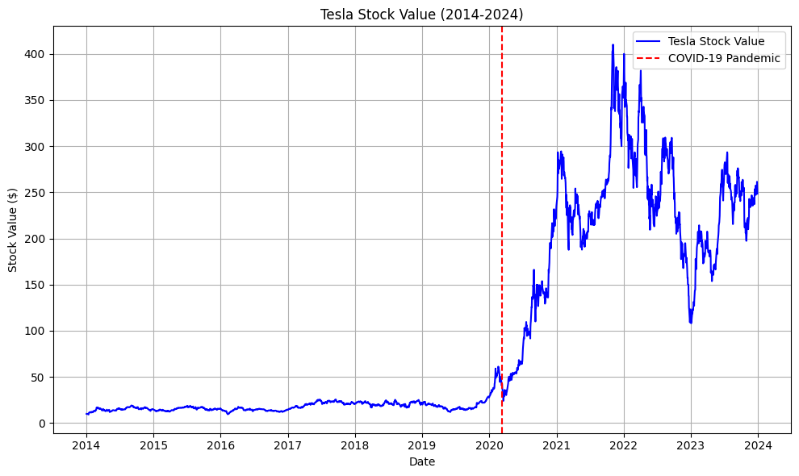

```python
# Plot Tesla Stock Value
plt.figure(figsize=(10, 6))
plt.plot(tesla_stock_df['date'], tesla_stock_df['close'], label='Tesla Stock Value', color='b')
plt.xlabel('Date')
plt.ylabel('Stock Value ($)')
plt.title('Tesla Stock Value (2014-2024)')
plt.grid(True)
plt.legend()
plt.tight_layout()
plt.axvline(pd.to_datetime('2020-03-11'), color='red', linestyle='--', label='COVID-19 Pandemic')
plt.legend()
plt.show()
```

**Overall Trend**: The stock value starts at a lower point in 2014 and remains relatively stable until around late 2019. Starting around early 2020, there is a sharp increase in stock value. The value peaks around 2021 before displaying volatility with several peaks and troughs.

**Covid-19 Impact**: The red dashed vertical line represents the start of the Covid-19 pandemic (around 2020). Despite initial fluctuations, Tesla’s stock value surged during the pandemic.

**Post-Pandemic Recovery**: After reaching a peak in late 2021, the stock value showed fluctuations. It remained above pre-pandemic levels, indicating sustained recovery.

Plot Tesla stock volume vs. date

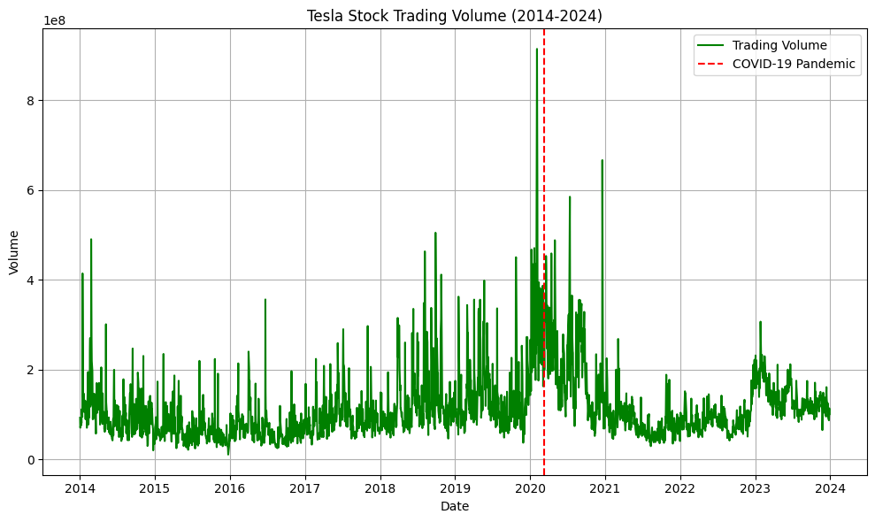

```python
# Plot Tesla Trading Volume
plt.figure(figsize=(10, 6))
plt.plot(tesla_stock_df['date'], tesla_stock_df['volume'], label='Trading Volume', color='g')
plt.xlabel('Date')
plt.ylabel('Volume')
plt.title('Tesla Stock Trading Volume (2014-2024)')
plt.grid(True)
plt.legend()
plt.tight_layout()
plt.axvline(pd.to_datetime('2020-03-11'), color='red', linestyle='--', label='COVID-19 Pandemic')
plt.legend()
plt.show()
```

**Overall Trend**: The green line shows the trading volume over time.From 2014 to 2016, the volume remained relatively low. Around 2017, there was a significant increase in trading volume.The period from 2017 to 2020 saw higher volatility in volume.

**Covid-19 Impact**: The red dashed vertical line around 2020 represents the start of the Covid-19 pandemic.Around this time, there was a sharp spike in trading volume, possibly due to market uncertainty and investor reactions.

**Post-Pandemic Recovery**: After the initial surge, trading volume gradually stabilized. From 2021 to 2024, the volume remained relatively consistent.

Plot Tesla stock opening price vs. date

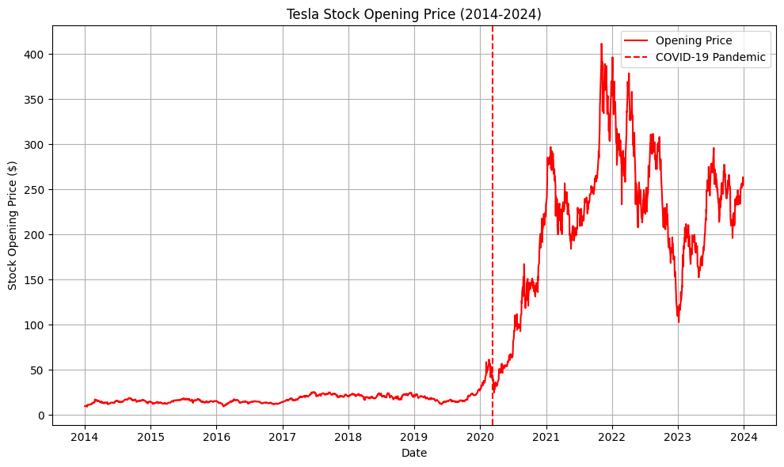

```python
plt.figure(figsize=(10, 6))
plt.plot(tesla_stock_df['date'], tesla_stock_df['open'], label='Opening Price', color='r')
plt.xlabel('Date')
plt.ylabel('Stock Opening Price ($)')
plt.title('Tesla Stock Opening Price (2014-2024)')
plt.grid(True)
plt.legend()
plt.tight_layout()
plt.axvline(pd.to_datetime('2020-03-11'), color='red', linestyle='--', label='COVID-19 Pandemic')
plt.legend()
plt.show()
```

**Overall Trend**: The opening price shows significant volatility over the years. From 2014 to 2016, the opening price remained relatively stable. Around 2017, there was an upward trend, leading to higher opening prices.

**Covid-19 Impact**: The red dashed vertical line around 2020 represents the start of the Covid-19 pandemic.Despite initial fluctuations, Tesla’s opening price surged during the pandemic.

**Post-Pandemic Recovery**: After reaching a peak in late 2021, the opening price showed fluctuations. It remained above pre-pandemic levels, indicating sustained recovery.

# Question: What was the effect of the Covid pandemic on Tesla’s stock value?

Finding Yearly returns using the new columns

```python
print(tesla_stock_df.groupby('year')['daily_returns'].sum())
```

```
year
2014      4.614000
2015      0.273333
2016     -0.428000
2017      6.902668
2018     -0.694001
2019      8.009333
2020    214.572668
2021    156.669998
2022   -291.826668
2023    140.320000
Name: daily_returns, dtype: float64
```

We see high yearly returns in the year 2020 and 2021 which is around the Covid pandemic time. Lets zoom in to that period to see how it behaves.

Filter data for the relevant period (around the Covid pandemic)

```python
start_date = '2020-01-01'
end_date = '2021-12-31'
filtered_tesla_stock_df = tesla_stock_df[(tesla_stock_df['date'] >= start_date) & (tesla_stock_df['date'] <= end_date)]
```

Create a Line plot

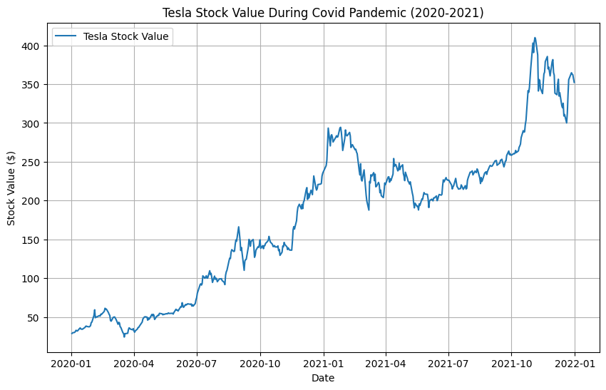

```python
plt.figure(figsize=(10, 6))
plt.plot(filtered_tesla_stock_df['date'], filtered_tesla_stock_df['close'], label='Tesla Stock Value')
plt.xlabel('Date')
plt.ylabel('Stock Value ($)')
plt.title('Tesla Stock Value During Covid Pandemic (2020-2021)')
plt.grid(True)
plt.legend()
plt.show()
```

# Question : Do Tesla’s stock prices and Dogecoin’s market value exhibit similar responses to Elon Musk’s tweets? Alternatively, does the market’s response to Dogecoin affect the share price of Tesla?

Change column names to lowercase in order to merge the datasets

```python
dogecoin_df.columns = dogecoin_df.columns.str.lower()
elon_tweets_df.columns = elon_tweets_df.columns.str.lower()
```

Display modified dataset

```python
print(dogecoin_df.head())
```

```
        date      open      high       low     close  adj close     volume
0 2017-11-09  0.001207  0.001415  0.001181  0.001415   0.001415  6259550.0
1 2017-11-10  0.001421  0.001431  0.001125  0.001163   0.001163  4246520.0
2 2017-11-11  0.001146  0.001257  0.001141  0.001201   0.001201  2231080.0
3 2017-11-12  0.001189  0.001210  0.001002  0.001038   0.001038  3288960.0
4 2017-11-13  0.001046  0.001212  0.001019  0.001211   0.001211  2481270.0
```

Create new date columns & clean tweets

```python
# Create new columns in elon_tweets_df
elon_tweets_df['year'] = elon_tweets_df['date'].dt.year

# Clean the tweets
def clean_text(text):
    text = re.sub(r'\n', '', text)
    text = re.sub(r'\xa0', '', text)
    text = re.sub(r'\t', '', text)
    text = re.sub(r'http\S+', '', text)
    text = re.sub(r'https\S+', '', text)
    text = re.sub(r'pic.twitter\S+', '', text)
    text = re.sub(r'#\S+', '', text)
    text = re.sub(r'@\S+', '', text)
    text = text.strip()
    text = ' '.join(text.split())
    text = text.lower()
    return text

elon_tweets_df['tweet'] = elon_tweets_df['tweet'].apply(clean_text)
```

Most Popular Tweet of Elon Musk on Dogecoin

```python
# Filter tweets mentioning Dogecoin
dogecoin_tweets_df = elon_tweets_df[elon_tweets_df['tweet'].str.contains('dogecoin')].reset_index(drop=True)
most_popular_dogetweets = dogecoin_tweets_df.sort_values('likes_count', ascending=False)[:10]['tweet']
for k, text in enumerate(most_popular_dogetweets):
    print(f"{k+1}. {text}")
```

```
1. dogecoin is the people’s crypto
2. bought some dogecoin for lil x, so he can be a toddler hodler
3. spacex is going to put a literal dogecoin on the literal moon
4. if major dogecoin holders sell most of their coins, it will get my full support. too much concentration is the only real issue imo.
5. dogecoin rulz
6. origin of doge day afternoon: the ancient romans sacrificed a dogecoin at the beginning of the doge days to appease the rage of sirius, believing that the star was the cause of the hot, sultry weather.
7. dogecoin value may vary
8. 2022: dogecoin is dumb
9. dogecoin might be my fav cryptocurrency. it’s pretty cool.
10. dogecoin mode
```

Plot Doge time series with Elon tweets to see the trend

```
No artists with labels found to put in legend.  Note that artists whose label start with an underscore are ignored when legend() is called with no argument.
```

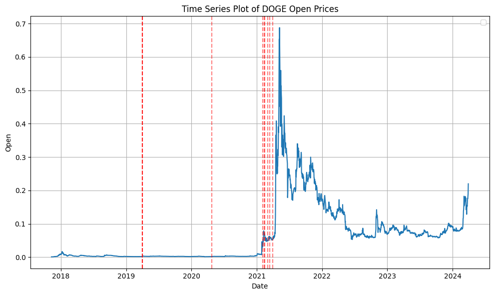

```python
plt.figure(figsize=(10, 6))
plt.plot(dogecoin_df['date'], dogecoin_df['open'])
plt.xlabel('Date')
plt.ylabel('Open')
plt.title('Time Series Plot of DOGE Open Prices')
plt.grid(True)
plt.tight_layout()
for tweet_date in dogecoin_tweets_df['date']:
    plt.axvline(x=tweet_date, color='r', linestyle='--', alpha=0.5)
plt.legend()
plt.grid(True)
plt.show()
```

**Price Movement:** The DOGE price surges sharply after Musk’s tweet, sending the cryptocurrency’s supporters into a flutter.We see a spike in early 2021 after series of tweets.

Elon Musk’s influence on Dogecoin’s price is evident, and his tweets have become a recurring trend affecting the cryptocurrency market

Plot the tesla price with Elon tweets to see the trend

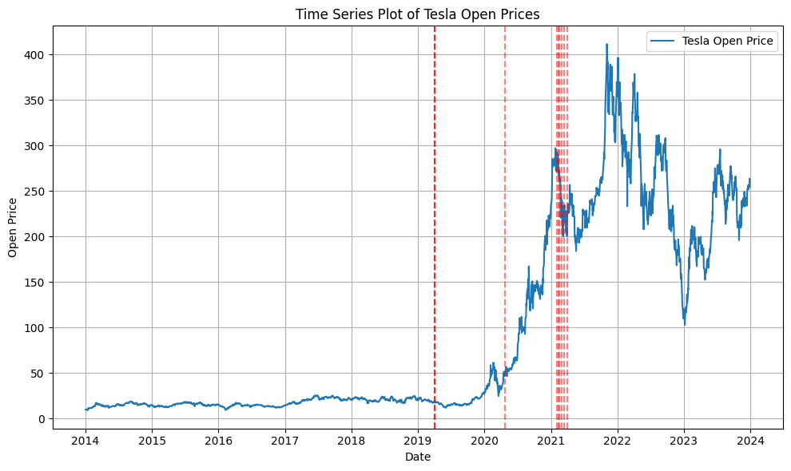

```python
# Plot Tesla open prices with Dogecoin tweet dates
plt.figure(figsize=(10, 6))
plt.plot(tesla_stock_df['date'], tesla_stock_df['open'], label='Tesla Open Price')
plt.xlabel('Date')
plt.ylabel('Open Price')
plt.title('Time Series Plot of Tesla Open Prices')
plt.grid(True)
for tweet_date in dogecoin_tweets_df['date']:
    plt.axvline(x=tweet_date, color='r', linestyle='--', alpha=0.5)
plt.legend()
plt.tight_layout()
plt.show()
```

# Section 2 Questions : How will Tesla stock prices trend in the future? Construct a predictive model.

Make date column datetime

```python
# Select and prepare the necessary columns
tsla = tesla_stock_df[['date', 'close']]
tsla["date"] = pd.to_datetime(tsla["date"])
doge = dogecoin_df[['date', 'close']]
doge.columns = ['date', 'close']
doge["date"] = pd.to_datetime(doge["date"])
```

Set date as index

```python
tsla.set_index('date', inplace=True)
doge.set_index('date', inplace=True)
```

Review ,Merge dates to match, and reset index.

```python
print(tsla.head())
print(doge.head())

#merge
tsla_and_doge = pd.merge(tsla, doge, on="date")
tsla_and_doge = tsla_and_doge.rename(columns={"close_x": "tsla_close", "close_y":"doge_close"})

#print
print(tsla_and_doge.head())

#reset
tsla_and_doge.reset_index(inplace=True)
```

```
                close
date
2014-01-02  10.006667
2014-01-03   9.970667
2014-01-06   9.800000
2014-01-07   9.957333
2014-01-08  10.085333
               close
date
2017-11-09  0.001415
2017-11-10  0.001163
2017-11-11  0.001201
2017-11-12  0.001038
2017-11-13  0.001211
            tsla_close  doge_close
date
2017-11-09   20.199333    0.001415
2017-11-10   20.199333    0.001163
2017-11-13   21.026667    0.001211
2017-11-14   20.580000    0.001184
2017-11-15   20.753332    0.001339
```

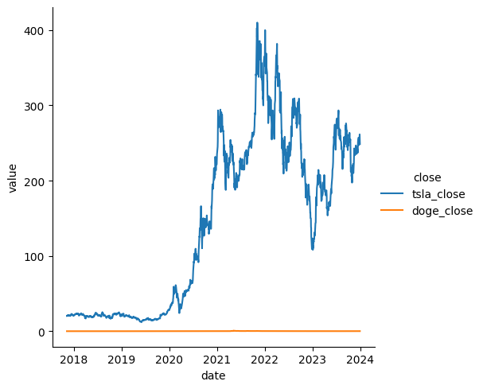

```python
# Visualize the merged data
tsla_doge_melt = tsla_and_doge.melt(id_vars='date', var_name='close')
sns.relplot(kind='line', data=tsla_doge_melt, x='date', y='value', hue='close')
plt.show()
```

Normalize data

```python
# Normalize the data
td = tsla_and_doge.copy()
cols = td.columns.difference(['date'])
sc = StandardScaler()
td[cols] = sc.fit_transform(td[cols])

print(td.head())
```

```
        date  tsla_close  doge_close
0 2017-11-09   -1.081142   -0.682857
1 2017-11-10   -1.081142   -0.685639
2 2017-11-13   -1.073867   -0.685109
3 2017-11-14   -1.077795   -0.685407
4 2017-11-15   -1.076270   -0.683696
```

Plot with normalization

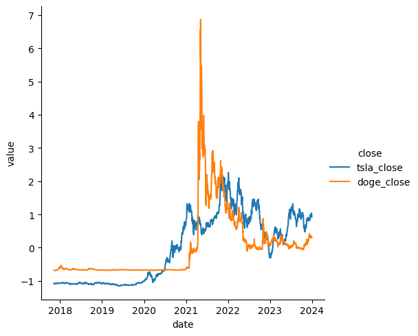

```python
# Plotting with normalized data
td_melt = td.melt(id_vars='date', var_name='close')
sns.relplot(kind='line', data=td_melt, x='date', y='value', hue='close')
plt.show()
```

Task 2, Build a predictive model:

```python
# Additional Tesla Stock Data Preparation and EDA
tsla1 = pd.read_csv(r"C:\Users\sgsin\OneDrive\Desktop\IST 652 Data\Tesla_Stock_2014_2023.csv")
tsla1 = tsla1[['date', 'open', 'high', 'low', 'close', 'volume']]
tsla1['date'] = pd.to_datetime(tsla1['date'])
```

Distribution plots of values

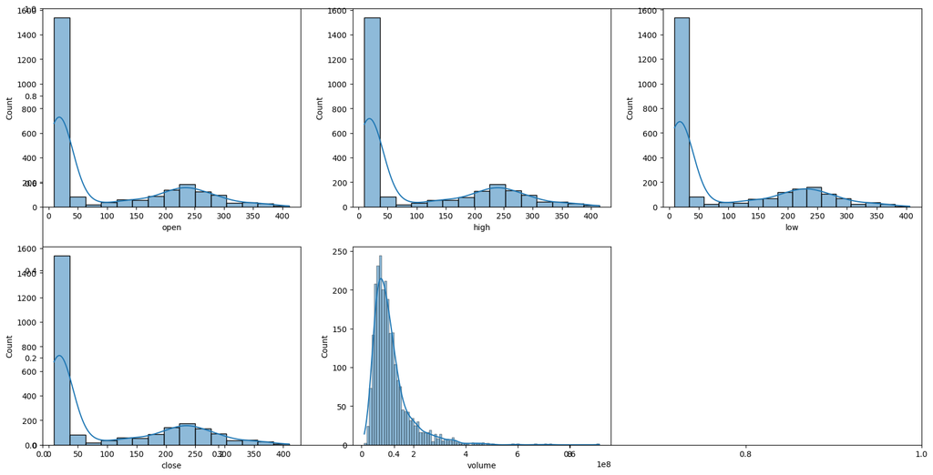

```python
# Distribution plots of values
features = ['open', 'high', 'low', 'close', 'volume']
plt.subplots(figsize=(20, 10))
for i, col in enumerate(features):
    plt.subplot(2, 3, i + 1)
    sns.histplot(tsla1[col], kde=True)
plt.show()
```

Determine outliers in the dataset

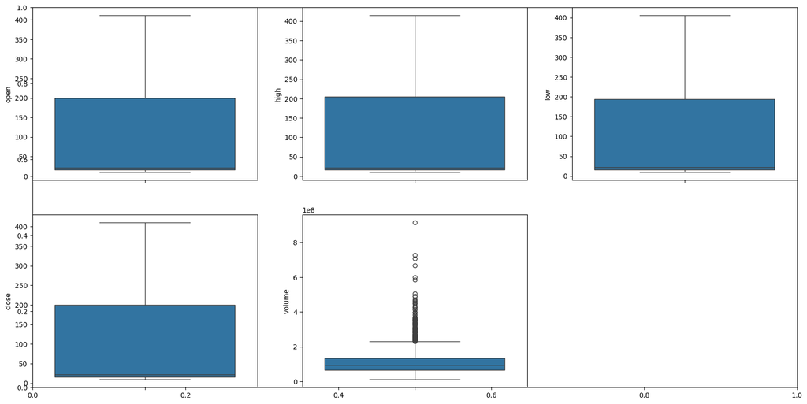

```python
# Determine outliers in the dataset
plt.subplots(figsize=(20, 10))
for i, col in enumerate(features):
    plt.subplot(2, 3, i + 1)
    sns.boxplot(tsla1[col])
plt.show()
```

Volume has many outliers above the data mean.

```
        date       open       high       low      close    volume  year  \
0 2014-01-02   9.986667  10.165333  9.770000  10.006667  92826000  2014
1 2014-01-03  10.000000  10.146000  9.906667   9.970667  70425000  2014
2 2014-01-06  10.000000  10.026667  9.682667   9.800000  80416500  2014
3 2014-01-07   9.841333  10.026667  9.683333   9.957333  75511500  2014
4 2014-01-08   9.923333  10.246667  9.917333  10.085333  92448000  2014

   month  day
0      1    2
1      1    3
2      1    6
3      1    7
4      1    8
        date       open       high       low      close    volume  year  \
0 2014-01-02   9.986667  10.165333  9.770000  10.006667  92826000  2014
1 2014-01-03  10.000000  10.146000  9.906667   9.970667  70425000  2014
2 2014-01-06  10.000000  10.026667  9.682667   9.800000  80416500  2014
3 2014-01-07   9.841333  10.026667  9.683333   9.957333  75511500  2014
4 2014-01-08   9.923333  10.246667  9.917333  10.085333  92448000  2014

   month  day  is_quarter_end
0      1    2               0
1      1    3               0
2      1    6               0
3      1    7               0
4      1    8               0
```

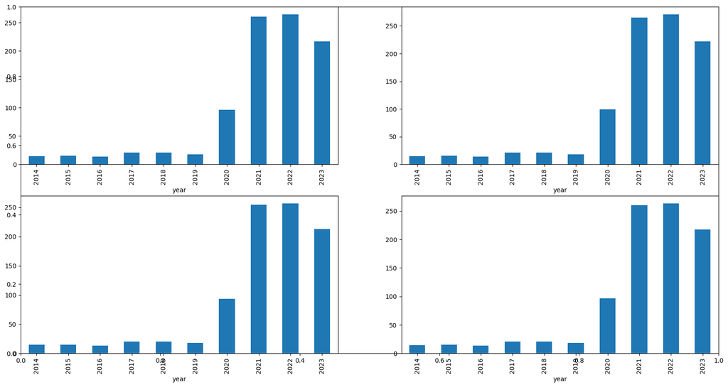

```python
# Separate day, month, year into three separate columns
tsla1['year'] = tsla1['date'].dt.year
tsla1['month'] = tsla1['date'].dt.month
tsla1['day'] = tsla1['date'].dt.day

print(tsla1.head())

# Add column for quarterly report data
tsla1['is_quarter_end'] = np.where(tsla1['month'] % 3 == 0, 1, 0)
print(tsla1.head())

# Plot yearly grouped data
tsla_grouped = tsla1.groupby('year').mean(numeric_only=True)
plt.subplots(figsize=(20, 10))
for i, col in enumerate(['open', 'high', 'low', 'close']):
    plt.subplot(2, 2, i + 1)
    tsla_grouped[col].plot(kind='bar')
plt.show()
```

TSLA stock appreciated at the fastest rate between 2019-2021.

```python
# Analyze quarterly data
print(tsla1.groupby('is_quarter_end').mean(numeric_only=True))
```

```
                     open       high        low      close        volume  \
is_quarter_end
0               92.942409  94.999027  90.710937  92.890010  1.142786e+08
1               96.364468  98.473195  94.127247  96.390155  1.110819e+08

                       year     month        day
is_quarter_end
0               2018.493998  6.098439  15.726891
1               2018.501176  7.425882  15.777647
```

Prices of stock are generally higher in quarter end months compared to non quarter end months. The volume of stock is lower in quarter end months.

Now adding more columns for training predictive model, including a target feature of whether or not to buy.

```python
# Add new features for predictive modeling
tsla1['open-close'] = tsla1['open'] - tsla1['close']
tsla1['low-high'] = tsla1['low'] - tsla1['high']
tsla1['target'] = np.where(tsla1['close'].shift(-1) > tsla1['close'], 1, 0)
print(tsla1.head())
```

```
        date       open       high       low      close    volume  year  \
0 2014-01-02   9.986667  10.165333  9.770000  10.006667  92826000  2014
1 2014-01-03  10.000000  10.146000  9.906667   9.970667  70425000  2014
2 2014-01-06  10.000000  10.026667  9.682667   9.800000  80416500  2014
3 2014-01-07   9.841333  10.026667  9.683333   9.957333  75511500  2014
4 2014-01-08   9.923333  10.246667  9.917333  10.085333  92448000  2014

   month  day  is_quarter_end  open-close  low-high  target
0      1    2               0   -0.020000 -0.395333       0
1      1    3               0    0.029333 -0.239333       0
2      1    6               0    0.200000 -0.344000       1
3      1    7               0   -0.116000 -0.343334       1
4      1    8               0   -0.162000 -0.329334       0
```

Check balance with pie chart

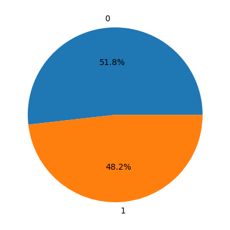

```python
# Check whether target is balanced with a pie chart
plt.pie(tsla1['target'].value_counts().values, labels=[0, 1], autopct='%1.1f%%')
plt.show()
```

Ensure no collinearity that can disrupt the predictive model

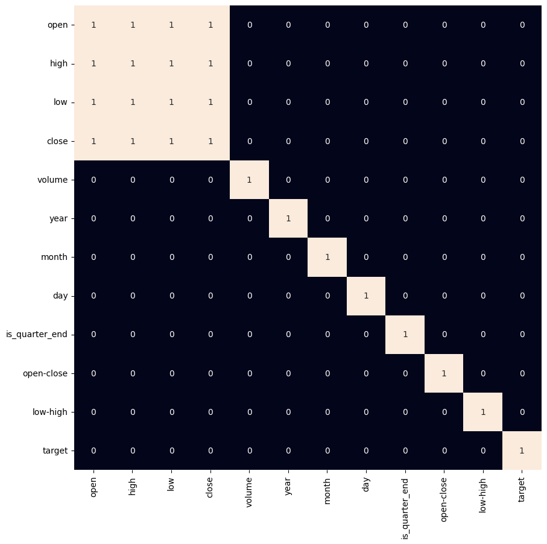

```python
# Ensure no collinearity that can disrupt the predictive model
plt.figure(figsize=(10, 10))
sns.heatmap(tsla1.corr(numeric_only=True) > 0.9, annot=True, cbar=False)
plt.show()
```

Next step: Split and Normalize the Data

```python
# Split and normalize data
features = tsla1[['open-close', 'low-high', 'is_quarter_end']]
target = tsla1['target']
scaler = StandardScaler()
features = scaler.fit_transform(features)
X_train, X_valid, Y_train, Y_valid = train_test_split(features, target, test_size=0.1, random_state=2022)
print(X_train.shape, X_valid.shape)
```

```
(2264, 3) (252, 3)
```

Train model

```python
# Train models
models = [LogisticRegression(), SVC(kernel='poly', probability=True), XGBClassifier()]
for model in models:
    model.fit(X_train, Y_train)
    print(f'{model} : ')
    print('Training Accuracy : ', roc_auc_score(Y_train, model.predict_proba(X_train)[:, 1]))
    print('Validation Accuracy : ', roc_auc_score(Y_valid, model.predict_proba(X_valid)[:, 1]))
    print()
```

```
LogisticRegression() :
Training Accuracy :  0.5150152532556302
Validation Accuracy :  0.5337616528092719

SVC(kernel='poly', probability=True) :
Training Accuracy :  0.49672854207327033
Validation Accuracy :  0.5196523053665911

XGBClassifier(base_score=None, booster=None, callbacks=None,
              colsample_bylevel=None, colsample_bynode=None,
              colsample_bytree=None, device=None, early_stopping_rounds=None,
              enable_categorical=False, eval_metric=None, feature_types=None,
              gamma=None, grow_policy=None, importance_type=None,
              interaction_constraints=None, learning_rate=None, max_bin=None,
              max_cat_threshold=None, max_cat_to_onehot=None,
              max_delta_step=None, max_depth=None, max_leaves=None,
              min_child_weight=None, missing=nan, monotone_constraints=None,
              multi_strategy=None, n_estimators=None, n_jobs=None,
              num_parallel_tree=None, random_state=None, ...) :
Training Accuracy :  0.9333894273795743
Validation Accuracy :  0.5433673469387755
```

From results: building confusion matrix from XGBClassifier (highest accuracy). Note that the model overfitted a lot during the training process, leading to a huge difference in accuracy in the validation exercise.

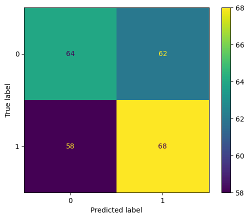

```python
# Confusion matrix for the best model (XGBClassifier)
best_model = models[2]
predictions = best_model.predict(X_valid)
cm = confusion_matrix(Y_valid, predictions)
disp = ConfusionMatrixDisplay(confusion_matrix=cm)
disp.plot()
plt.show()
```

Prophet for data forecasting

```python
# Prophet Model for Future Predictions
tsla_prophet = tesla_stock_df[['date', 'close']]
tsla_prophet.columns = ['ds', 'y']
tsla_prophet['ds'] = pd.to_datetime(tsla_prophet['ds'])
```

Train prophet model

```python
def train_prophet_model(data):
    model = Prophet(
        changepoint_prior_scale=0.05,
        holidays_prior_scale=15,
        seasonality_prior_scale=10,
        weekly_seasonality=True,
        yearly_seasonality=True,
        daily_seasonality=False
    )
    model.add_country_holidays(country_name='US')
    model.fit(data)
    return model
```

```python
model = train_prophet_model(tsla_prophet)
```

```
12:26:10 - cmdstanpy - INFO - Chain [1] start processing
12:26:11 - cmdstanpy - INFO - Chain [1] done processing
```

Generate forecast

```python
def generate_forecast(model, periods=365):
    future = model.make_future_dataframe(periods=periods)
    forecast = model.predict(future)
    return forecast

def plot_forecast(model, forecast):
    model.plot(forecast)
```

Plot forecast

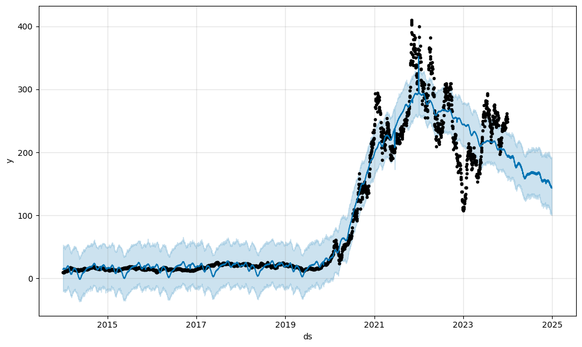

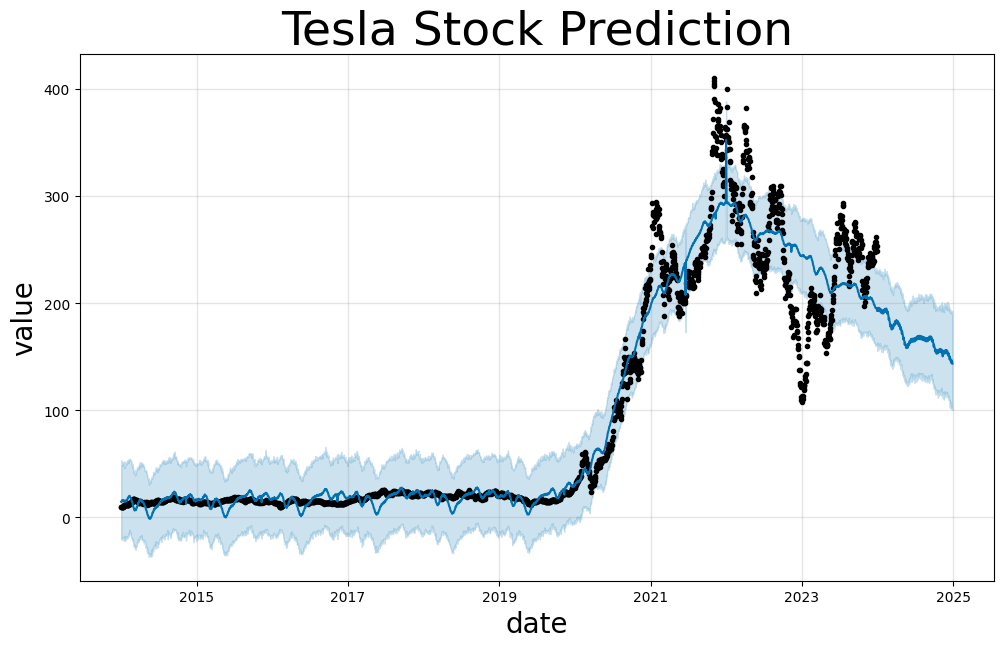

```python
forecast = generate_forecast(model)

plot_forecast(model, forecast)
fig = model.plot(forecast, xlabel='Date', ylabel='Value')
ax = fig.gca()
ax.set_title("Tesla Stock Prediction", size=34)
ax.set_xlabel("date", size=20)
ax.set_ylabel("value", size=20)
ax.tick_params(axis="x", labelsize=10)
ax.tick_params(axis="y", labelsize=10)
plt.show()
```

# Section 3 Question: How do Elon Musk's tweets affect stock market Movements? Can this sentiment be measure though sentiment analysis?

```python
import re
from textblob import TextBlob

# Function to remove emojis from text
def remove_emojis(text):
    emoji_pattern = re.compile("["
                               u"\U0001F600-\U0001F64F"  # emoticons
                               u"\U0001F300-\U0001F5FF"  # symbols & pictographs
                               u"\U0001F680-\U0001F6FF"  # transport & map symbols
                               u"\U0001F1E0-\U0001F1FF"  # flags (iOS)
                               u"\U00002500-\U00002BEF"  # chinese char
                               u"\U00002702-\U000027B0"
                               u"\U00002702-\U000027B0"
                               u"\U000024C2-\U0001F251"
                               u"\U0001f926-\U0001f937"
                               u"\U00010000-\U0010ffff"
                               u"\u2640-\u2642"
                               u"\u2600-\u2B55"
                               u"\u200d"
                               u"\u23cf"
                               u"\u23e9"
                               u"\u231a"
                               u"\ufe0f"  # dingbats
                               u"\u3030"
                               "]+", flags=re.UNICODE)
    return emoji_pattern.sub(r'', text)

# Modify clean_text function to remove emojis
def clean_text(text):
    text = re.sub(r'\n', '', text)
    text = re.sub(r'\xa0', '', text)
    text = re.sub(r'\t', '', text)
    text = re.sub(r'http\S+', '', text)
    text = re.sub(r'https\S+', '', text)
    text = re.sub(r'pic.twitter\S+', '', text)
    text = re.sub(r'#\S+', '', text)
    text = re.sub(r'@\S+', '', text)
    text = remove_emojis(text)  # Remove emojis
    text = text.strip()
    text = ' '.join(text.split())
    text = text.lower()
    return text

# Apply sentiment analysis to the cleaned tweet text
elon_tweets_df['cleaned_tweet'] = elon_tweets_df['tweet'].apply(clean_text)
elon_tweets_df['sentiment'] = elon_tweets_df['cleaned_tweet'].apply(lambda x: TextBlob(x).sentiment.polarity)

# Print or store the sentiment scores along with the tweets
print(elon_tweets_df[['cleaned_tweet', 'sentiment']].head())
```

```
                            cleaned_tweet  sentiment
0  for now. costs are decreasing rapidly.      0.000
1                love this beautiful shot      0.675
2                         trust the shrub      0.000
3      the art in cyberpunk is incredible      0.900
4                                              0.000
```

```python
print(elon_tweets_df.head())
```

```
        date      time                                   tweet  replies_count  \
0 2021-04-11  18:50:33  for now. costs are decreasing rapidly.            640
1 2021-04-11  18:48:58                love this beautiful shot           2464
2 2021-04-11  17:49:38                         trust the shrub            115
3 2021-04-11  15:23:49      the art in cyberpunk is incredible           8437
4 2021-04-11   9:18:47                                      🤣🤣            446

   retweets_count  likes_count  total_engagement  year  \
0             444        15281             16365  2021
1            1517        71161             75142  2021
2              48         1380              1543  2021
3           10329       228144            246910  2021
4             542         7489              8477  2021

                            cleaned_tweet  sentiment
0  for now. costs are decreasing rapidly.      0.000
1                love this beautiful shot      0.675
2                         trust the shrub      0.000
3      the art in cyberpunk is incredible      0.900
4                                              0.000
```

```
date
2010-06-04       5457
2011-12-01        357
2011-12-03        148
2011-12-04         91
2011-12-21       2004
               ...
2021-04-13      29369
2021-04-14     125614
2021-04-15    1140925
2021-04-16     868441
2021-04-17     761846
Name: total_engagement, Length: 2037, dtype: int64
```

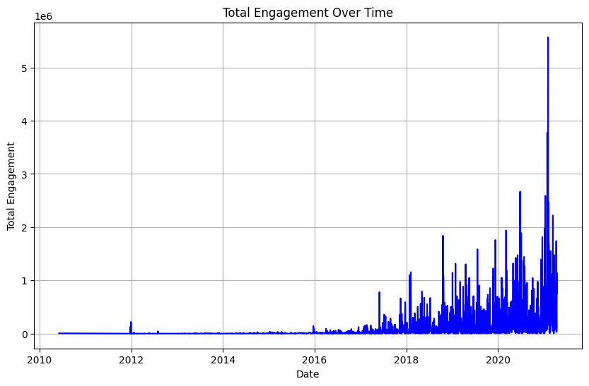

```python
# Calculate total engagement by summing replies, likes, and retweets
elon_tweets_df['total_engagement'] = elon_tweets_df['replies_count'] + elon_tweets_df['retweets_count'] + elon_tweets_df['likes_count']

# Group by date and sum total engagement
total_engagement_over_time = elon_tweets_df.groupby('date')['total_engagement'].sum()

# Print the total engagement over time
print(total_engagement_over_time)

import matplotlib.pyplot as plt

# Plot total engagement over time
plt.figure(figsize=(10, 6))
plt.plot(total_engagement_over_time.index, total_engagement_over_time.values, color='b')
plt.title('Total Engagement Over Time')
plt.xlabel('Date')
plt.ylabel('Total Engagement')
plt.grid(True)
plt.show()
```

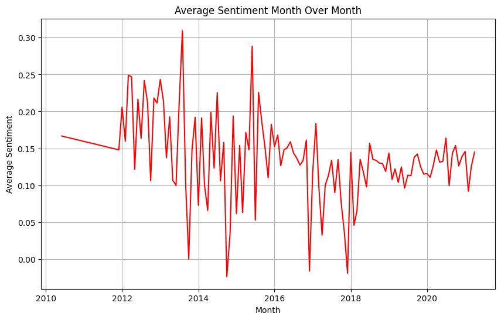

```python
# Extract month from the date column
elon_tweets_df['month'] = elon_tweets_df['date'].dt.to_period('M')

# Group by month and calculate average sentiment
average_sentiment_over_time = elon_tweets_df.groupby('month')['sentiment'].mean()

# Plot sentiment month over month
plt.figure(figsize=(10, 6))
plt.plot(average_sentiment_over_time.index.to_timestamp(), average_sentiment_over_time.values, color='r')
plt.title('Average Sentiment Month Over Month')
plt.xlabel('Month')
plt.ylabel('Average Sentiment')
plt.grid(True)
plt.show()
```

```python
# Group by month and calculate mean positive sentiment
monthly_positive_sentiment = elon_tweets_df.resample('M', on='date')['sentiment'].mean()

# Filter months with positive sentiment greater than 0
positive_months = monthly_positive_sentiment[monthly_positive_sentiment > 0]

# Sort the results by mean positive sentiment in descending order and select the top 10 months
top_10_positive_months = positive_months.sort_values(ascending=False).head(10)

# Print the top 10 months with the highest average positive sentiment
print("Top 10 Months of Positive Sentiment:")
print(top_10_positive_months)
```

```
Top 10 Months of Positive Sentiment:
date
2013-08-31    0.309252
2015-06-30    0.288456
2012-03-31    0.249142
2012-04-30    0.246912
2013-01-31    0.243333
2012-08-31    0.241851
2015-08-31    0.225667
2014-07-31    0.225532
2012-11-30    0.218164
2012-06-30    0.216736
Name: sentiment, dtype: float64
```

```python
# Filter months with negative sentiment less than 0
negative_months = monthly_positive_sentiment[monthly_positive_sentiment < 0]

# Sort the results by mean negative sentiment in ascending order (since negative sentiment scores are negative values)
top_10_negative_months = negative_months.sort_values().head(10)

# Print the top 10 months with the highest average negative sentiment
print("Top 10 Months of Negative Sentiment:")
print(top_10_negative_months)
```

```
Top 10 Months of Negative Sentiment:
date
2014-10-31   -0.023854
2017-12-31   -0.019298
2016-12-31   -0.016591
Name: sentiment, dtype: float64
```

```python
# Calculate the length of each comment
elon_tweets_df['comment_length'] = elon_tweets_df['tweet'].apply(len)

# Calculate the average comment length
average_comment_length = elon_tweets_df['comment_length'].mean()

print("Average comment length:", average_comment_length)
```

```
Average comment length: 68.34055086769622
```

```python
# Filter positive tweets
positive_tweets = elon_tweets_df[elon_tweets_df['sentiment'] > 0]

# Calculate average length of positive tweets
average_length_positive = positive_tweets['tweet'].apply(len).mean()

# Filter negative tweets
negative_tweets = elon_tweets_df[elon_tweets_df['sentiment'] < 0]

# Calculate average length of negative tweets
average_length_negative = negative_tweets['tweet'].apply(len).mean()

print("Average length of positive tweets:", average_length_positive)
print("Average length of negative tweets:", average_length_negative)
```

```
Average length of positive tweets: 85.67344497607655
Average length of negative tweets: 101.24270072992701
```

```python
# Calculate average sentiment score for positive tweets
average_score_positive = positive_tweets['sentiment'].mean()

# Calculate average sentiment score for negative tweets
average_score_negative = negative_tweets['sentiment'].mean()

print("Average sentiment score of positive tweets:", average_score_positive)
print("Average sentiment score of negative tweets:", average_score_negative)
```

```
Average sentiment score of positive tweets: 0.33130066531505176
Average sentiment score of negative tweets: -0.21376565448108883
```

```python
from collections import Counter
import nltk
from nltk.corpus import stopwords

# Download stopwords if not already downloaded
nltk.download('stopwords')

# Get the set of stopwords
stop_words = set(stopwords.words('english'))

# Tokenize positive tweets
positive_words = ' '.join(positive_tweets['tweet']).lower().split()
# Tokenize negative tweets
negative_words = ' '.join(negative_tweets['tweet']).lower().split()

# Remove stopwords
positive_words = [word for word in positive_words if word not in stop_words]
negative_words = [word for word in negative_words if word not in stop_words]

# Count occurrences of each word
positive_word_counts = Counter(positive_words)
negative_word_counts = Counter(negative_words)

# Get top 10 words for positive and negative tweets
top_10_positive_words = positive_word_counts.most_common(10)
top_10_negative_words = negative_word_counts.most_common(10)

print("Top 10 words from positive tweets:")
for word, count in top_10_positive_words:
    print(f"{word}: {count}")

print("\nTop 10 words from negative tweets:")
for word, count in top_10_negative_words:
    print(f"{word}: {count}")
```

```
Top 10 words from positive tweets:
&amp;: 1230
tesla: 577
good: 397
great: 325
much: 265
would: 242
like: 222
model: 218
high: 212
it’s: 211

Top 10 words from negative tweets:
&amp;: 396
tesla: 154
boring: 83
it’s: 78
like: 70
hard: 68
would: 65
model: 61
long: 57
get: 55
```

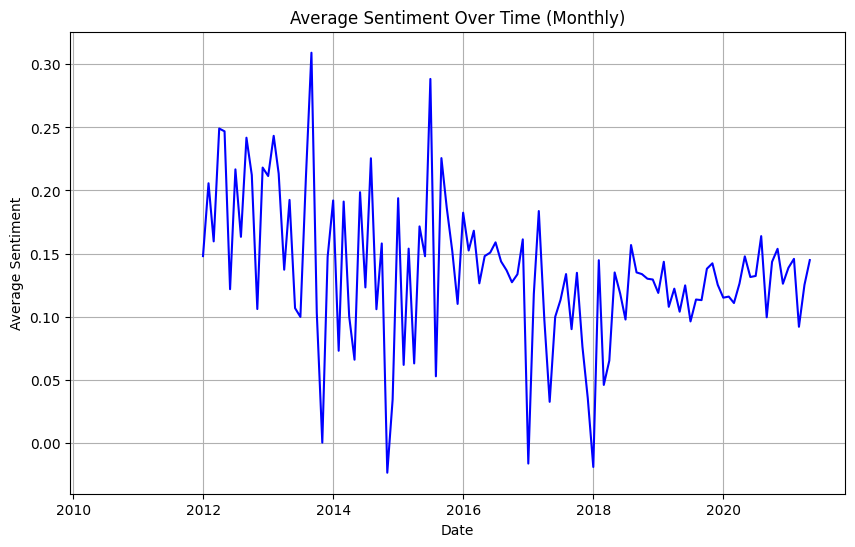

```python
# Group by month and calculate the mean sentiment
monthly_average_sentiment = elon_tweets_df.resample('M', on='date')['sentiment'].mean()

# Plot average sentiment over time
plt.figure(figsize=(10, 6))
plt.plot(monthly_average_sentiment.index, monthly_average_sentiment.values, color='b')
plt.title('Average Sentiment Over Time (Monthly)')
plt.xlabel('Date')
plt.ylabel('Average Sentiment')
plt.grid(True)
plt.show()
```

```python
# Calculate daily percentage change in price
dogecoin_df['daily_percentage_change'] = dogecoin_df['close'].pct_change() * 100

# Print the head of the dataframe with the new column
print(dogecoin_df.head())
```

```
        date      open      high       low     close  adj close     volume  \
0 2017-11-09  0.001207  0.001415  0.001181  0.001415   0.001415  6259550.0
1 2017-11-10  0.001421  0.001431  0.001125  0.001163   0.001163  4246520.0
2 2017-11-11  0.001146  0.001257  0.001141  0.001201   0.001201  2231080.0
3 2017-11-12  0.001189  0.001210  0.001002  0.001038   0.001038  3288960.0
4 2017-11-13  0.001046  0.001212  0.001019  0.001211   0.001211  2481270.0

   daily_percentage_change
0                      NaN
1               -17.809187
2                 3.267412
3               -13.572023
4                16.666667
```

```python
# Calculate daily percentage change in price
tesla_stock_df['daily_percentage_change'] = tesla_stock_df['close'].pct_change() * 100

# Print the head of the dataframe with the new column
print(tesla_stock_df.head())
```

```
        date       open       high       low      close    volume      rsi_7  \
0 2014-01-02   9.986667  10.165333  9.770000  10.006667  92826000  55.344071
1 2014-01-03  10.000000  10.146000  9.906667   9.970667  70425000  53.742629
2 2014-01-06  10.000000  10.026667  9.682667   9.800000  80416500  46.328174
3 2014-01-07   9.841333  10.026667  9.683333   9.957333  75511500  53.263037
4 2014-01-08   9.923333  10.246667  9.917333  10.085333  92448000  58.368660

      rsi_14       cci_7     cci_14  ...  bollinger  TrueRange     atr_7  \
0  54.440118  -37.373644  15.213422  ...   9.740800   0.395333  0.402641
1  53.821521  -81.304471  17.481130  ...   9.776167   0.239333  0.379311
2  50.870410 -123.427544 -37.824708  ...   9.797900   0.344000  0.374267
3  53.406750  -84.784651 -20.779431  ...   9.837900   0.343334  0.369848
4  55.423026   60.799662  43.570559  ...   9.870167   0.329334  0.364060

     atr_14  next_day_close  year  month  day  daily_returns  \
0  0.447550        9.970667  2014      1    2      -0.036000
1  0.432677        9.800000  2014      1    3      -0.170667
2  0.426343        9.957333  2014      1    6       0.157333
3  0.420414       10.085333  2014      1    7       0.128000
4  0.413908        9.835333  2014      1    8      -0.250000

   daily_percentage_change
0                      NaN
1                -0.359760
2                -1.711691
3                 1.605439
4                 1.285485

[5 rows x 25 columns]
```

```python
# Select required columns from each DataFrame
doge_subset = dogecoin_df[['date', 'close', 'daily_percentage_change']].copy()
tesla_subset = tesla_stock_df[['date', 'close', 'daily_percentage_change']].copy()

# Rename columns to differentiate between Tesla and Dogecoin
doge_subset.rename(columns={'close': 'dogecoin_close', 'daily_percentage_change': 'dogecoin_daily_change'}, inplace=True)
tesla_subset.rename(columns={'close': 'tesla_close', 'daily_percentage_change': 'tesla_daily_change'}, inplace=True)

# Concatenate the DataFrames
combined_df = pd.concat([doge_subset, tesla_subset], axis=1)

# Print the new DataFrame
print(combined_df.head())
```

```
        date  dogecoin_close  dogecoin_daily_change       date  tesla_close  \
0 2017-11-09        0.001415                    NaN 2014-01-02    10.006667
1 2017-11-10        0.001163             -17.809187 2014-01-03     9.970667
2 2017-11-11        0.001201               3.267412 2014-01-06     9.800000
3 2017-11-12        0.001038             -13.572023 2014-01-07     9.957333
4 2017-11-13        0.001211              16.666667 2014-01-08    10.085333

   tesla_daily_change
0                 NaN
1           -0.359760
2           -1.711691
3            1.605439
4            1.285485
```

```python
import pandas as pd

# Filter data for the years 2018 to May 2021
tesla_stock_filtered = tesla_stock_df[(tesla_stock_df['date'].dt.year >= 2018) & (tesla_stock_df['date'] < '2021-06-01')]
dogecoin_filtered = dogecoin_df[(dogecoin_df['date'].dt.year >= 2018) & (dogecoin_df['date'] < '2021-06-01')]

# Group by week and calculate weekly average closing prices
tesla_weekly_avg = tesla_stock_filtered.resample('W-Mon', on='date')['close'].mean()
dogecoin_weekly_avg = dogecoin_filtered.resample('W-Mon', on='date')['close'].mean()

# Calculate weekly change in price for Tesla and Dogecoin
tesla_weekly_change = tesla_weekly_avg.diff()
dogecoin_weekly_change = dogecoin_weekly_avg.diff()

# Ensure all arrays have the same length
length = min(len(tesla_weekly_avg), len(dogecoin_weekly_avg), len(tesla_weekly_change), len(dogecoin_weekly_change))

# Create a new DataFrame with weekly averages and changes
weekly_summary_df = pd.DataFrame({
    'Date': tesla_weekly_avg.index[:length],
    'Tesla_Weekly_Avg_Close': tesla_weekly_avg.values[:length],
    'Dogecoin_Weekly_Avg_Close': dogecoin_weekly_avg.values[:length],
    'Tesla_Weekly_Price_Change': tesla_weekly_change.values[:length],
    'Dogecoin_Weekly_Price_Change': dogecoin_weekly_change.values[:length]
})

# Print the new DataFrame
print(weekly_summary_df.head())
```

```
        Date  Tesla_Weekly_Avg_Close  Dogecoin_Weekly_Avg_Close  \
0 2018-01-08               21.405200                   0.008909
1 2018-01-15               22.377667                   0.012467
2 2018-01-22               23.111600                   0.012230
3 2018-01-29               23.049333                   0.007518
4 2018-02-05               23.016801                   0.007209

   Tesla_Weekly_Price_Change  Dogecoin_Weekly_Price_Change
0                        NaN                           NaN
1                   0.972467                      0.003558
2                   0.733933                     -0.000237
3                  -0.062266                     -0.004713
4                  -0.032533                     -0.000308
```

```python
# Calculate weekly percentage change for Tesla and Dogecoin
tesla_weekly_percentage_change = tesla_weekly_avg.pct_change() * 100
dogecoin_weekly_percentage_change = dogecoin_weekly_avg.pct_change() * 100

# Ensure all arrays have the same length
length = min(len(tesla_weekly_avg), len(dogecoin_weekly_avg), len(tesla_weekly_change), len(dogecoin_weekly_change),
             len(tesla_weekly_percentage_change), len(dogecoin_weekly_percentage_change))

# Create a new DataFrame with weekly averages, changes, and percentage changes
weekly_summary_df = pd.DataFrame({
    'Date': tesla_weekly_avg.index[:length],
    'Tesla_Weekly_Avg_Close': tesla_weekly_avg.values[:length],
    'Dogecoin_Weekly_Avg_Close': dogecoin_weekly_avg.values[:length],
    'Tesla_Weekly_Price_Change': tesla_weekly_change.values[:length],
    'Dogecoin_Weekly_Price_Change': dogecoin_weekly_change.values[:length],
    'Tesla_Weekly_Percentage_Change': tesla_weekly_percentage_change.values[:length],
    'Dogecoin_Weekly_Percentage_Change': dogecoin_weekly_percentage_change.values[:length]
})

# Print the new DataFrame
print(weekly_summary_df.head())
```

```
        Date  Tesla_Weekly_Avg_Close  Dogecoin_Weekly_Avg_Close  \
0 2018-01-08               21.405200                   0.008909
1 2018-01-15               22.377667                   0.012467
2 2018-01-22               23.111600                   0.012230
3 2018-01-29               23.049333                   0.007518
4 2018-02-05               23.016801                   0.007209

   Tesla_Weekly_Price_Change  Dogecoin_Weekly_Price_Change  \
0                        NaN                           NaN
1                   0.972467                      0.003558
2                   0.733933                     -0.000237
3                  -0.062266                     -0.004713
4                  -0.032533                     -0.000308

   Tesla_Weekly_Percentage_Change  Dogecoin_Weekly_Percentage_Change
0                             NaN                                NaN
1                        4.543132                          39.941953
2                        3.279756                          -1.903245
3                       -0.269416                         -38.532432
4                       -0.141144                          -4.100868
```

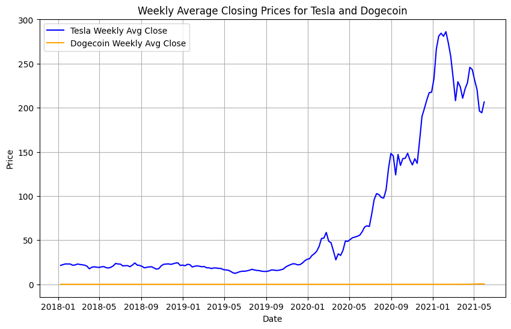

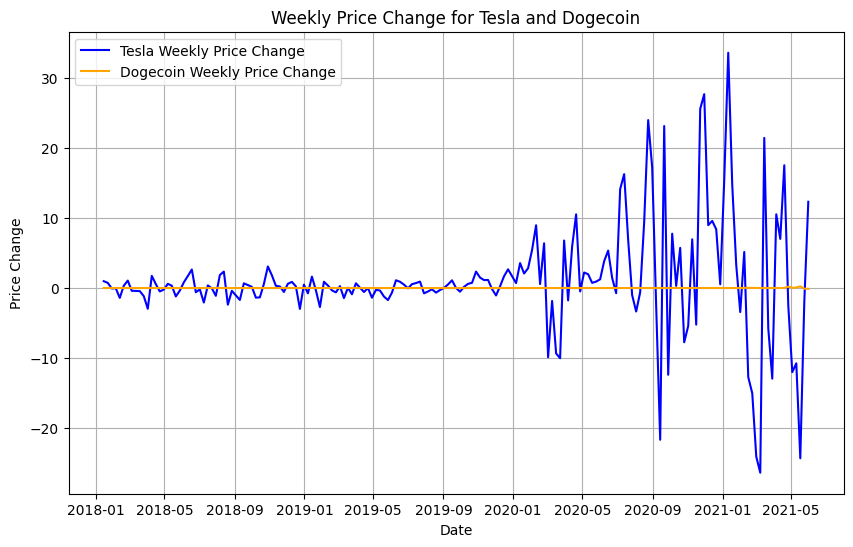

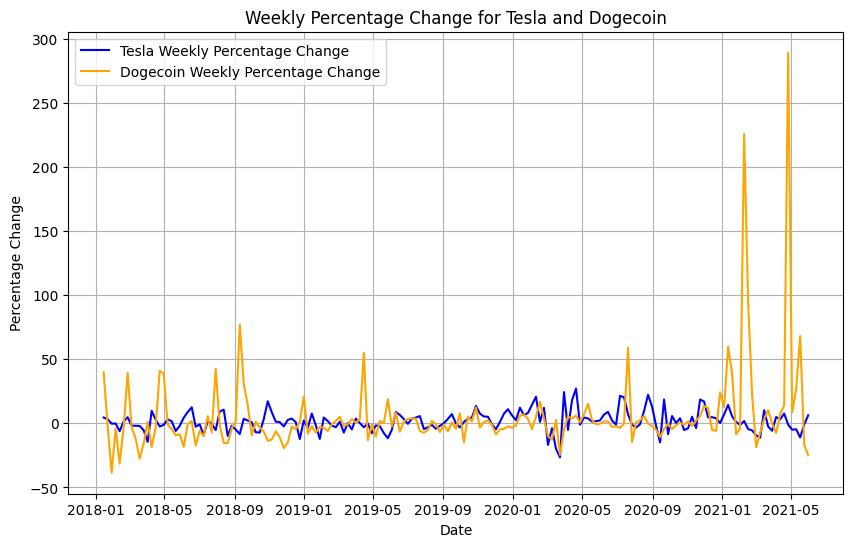

```python
import matplotlib.pyplot as plt

# Plotting the weekly average closing prices for Tesla and Dogecoin
plt.figure(figsize=(10, 6))
plt.plot(weekly_summary_df['Date'], weekly_summary_df['Tesla_Weekly_Avg_Close'], label='Tesla Weekly Avg Close', color='blue')
plt.plot(weekly_summary_df['Date'], weekly_summary_df['Dogecoin_Weekly_Avg_Close'], label='Dogecoin Weekly Avg Close', color='orange')

# Adding titles and labels
plt.title('Weekly Average Closing Prices for Tesla and Dogecoin')
plt.xlabel('Date')
plt.ylabel('Price')
plt.legend()
plt.grid(True)
plt.show()

# Plotting the weekly price change for Tesla and Dogecoin
plt.figure(figsize=(10, 6))
plt.plot(weekly_summary_df['Date'], weekly_summary_df['Tesla_Weekly_Price_Change'], label='Tesla Weekly Price Change', color='blue')
plt.plot(weekly_summary_df['Date'], weekly_summary_df['Dogecoin_Weekly_Price_Change'], label='Dogecoin Weekly Price Change', color='orange')

# Adding titles and labels
plt.title('Weekly Price Change for Tesla and Dogecoin')
plt.xlabel('Date')
plt.ylabel('Price Change')
plt.legend()
plt.grid(True)
plt.show()

# Plotting the weekly percentage change for Tesla and Dogecoin
plt.figure(figsize=(10, 6))
plt.plot(weekly_summary_df['Date'], weekly_summary_df['Tesla_Weekly_Percentage_Change'], label='Tesla Weekly Percentage Change', color='blue')
plt.plot(weekly_summary_df['Date'], weekly_summary_df['Dogecoin_Weekly_Percentage_Change'], label='Dogecoin Weekly Percentage Change', color='orange')

# Adding titles and labels
plt.title('Weekly Percentage Change for Tesla and Dogecoin')
plt.xlabel('Date')
plt.ylabel('Percentage Change')
plt.legend()
plt.grid(True)
plt.show()
```

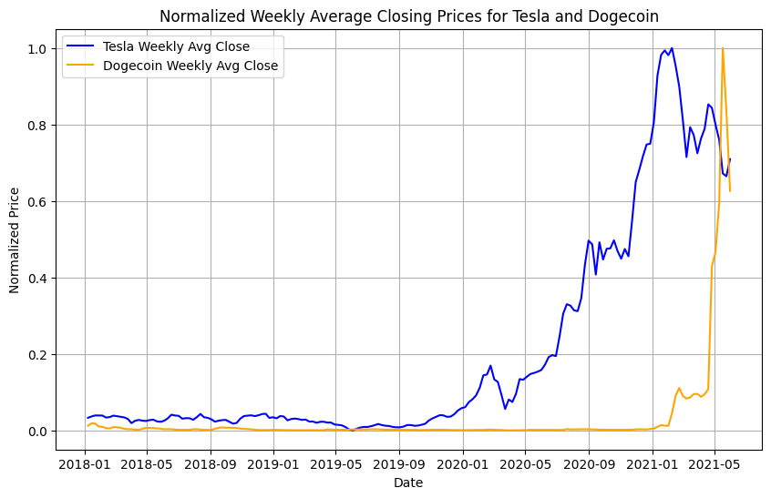

```python
from sklearn.preprocessing import MinMaxScaler

# Normalize the data
scaler = MinMaxScaler()

# Normalize weekly average closing prices
weekly_summary_df['Tesla_Weekly_Avg_Close_Normalized'] = scaler.fit_transform(weekly_summary_df['Tesla_Weekly_Avg_Close'].values.reshape(-1, 1))
weekly_summary_df['Dogecoin_Weekly_Avg_Close_Normalized'] = scaler.fit_transform(weekly_summary_df['Dogecoin_Weekly_Avg_Close'].values.reshape(-1, 1))

# Normalize weekly price changes
weekly_summary_df['Tesla_Weekly_Price_Change_Normalized'] = scaler.fit_transform(weekly_summary_df['Tesla_Weekly_Price_Change'].values.reshape(-1, 1))
weekly_summary_df['Dogecoin_Weekly_Price_Change_Normalized'] = scaler.fit_transform(weekly_summary_df['Dogecoin_Weekly_Price_Change'].values.reshape(-1, 1))

# Normalize weekly percentage changes
weekly_summary_df['Tesla_Weekly_Percentage_Change_Normalized'] = scaler.fit_transform(weekly_summary_df['Tesla_Weekly_Percentage_Change'].values.reshape(-1, 1))
weekly_summary_df['Dogecoin_Weekly_Percentage_Change_Normalized'] = scaler.fit_transform(weekly_summary_df['Dogecoin_Weekly_Percentage_Change'].values.reshape(-1, 1))

# Plotting the normalized data
plt.figure(figsize=(10, 6))

# Plotting the normalized weekly average closing prices
plt.plot(weekly_summary_df['Date'], weekly_summary_df['Tesla_Weekly_Avg_Close_Normalized'], label='Tesla Weekly Avg Close', color='blue')
plt.plot(weekly_summary_df['Date'], weekly_summary_df['Dogecoin_Weekly_Avg_Close_Normalized'], label='Dogecoin Weekly Avg Close', color='orange')

# Adding titles and labels
plt.title('Normalized Weekly Average Closing Prices for Tesla and Dogecoin')
plt.xlabel('Date')
plt.ylabel('Normalized Price')
plt.legend()
plt.grid(True)
plt.show()

# Repeat similar steps for other plots...
```